# Predicting Flight Delays at the Pittsburgh Airport

```r
mean.cv.errors =apply(cv.errors ,2, mean)
mean.cv.errors
```

```
##        1        2        3        4        5        6        7
## 1641.944 1639.012 1636.455 1634.591 1632.953 1630.978 1630.040
```

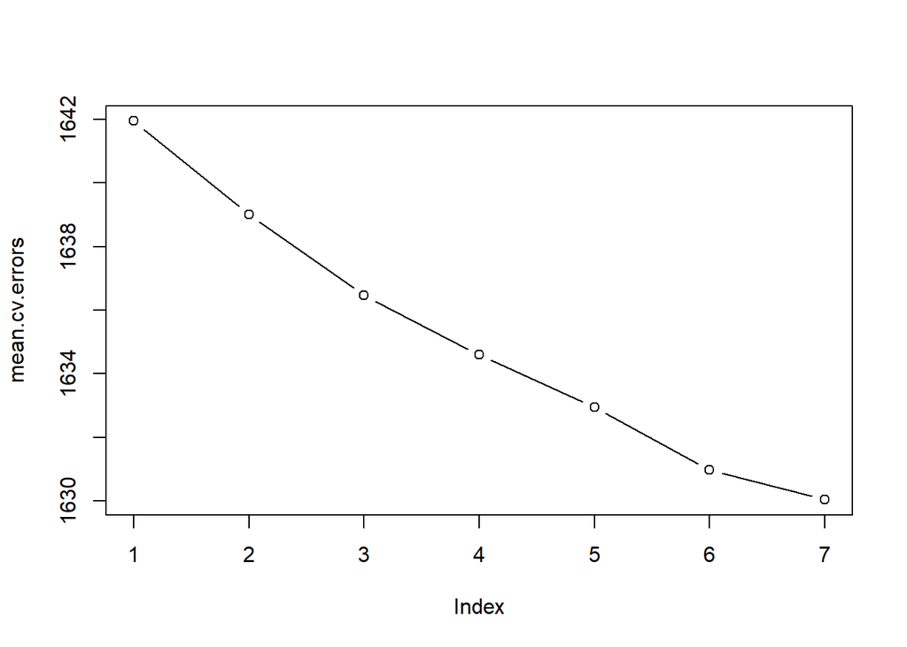

```r
par(mfrow =c(1,1))
plot(mean.cv.errors ,type='b')
```

**Interpretation:**

From the results of cross validation, it can be noticed that the Mean Cross validation error is lowest for 7 variable model. But it may be noted that the reduction in Mean cv error comes to 1630 only and that is quite high.

```r
# Best variables as per cross validation
reg.best=regsubsets (ArrDelayNew∼Month + DayOfMonth + DayOfWeek + Carrier + OriginCity + AdjArrTime + Distance,data=PIT_2019_ArrivePit.df , nvmax =7,method ="forward", subset=train)
```

```
## Reordering variables and trying again:
```

```r
coef(reg.best ,7)
```

```
##            (Intercept)              MonthJune              MonthJuly
##              13.273573               8.026938               4.416368
##               MonthNov           CarrierDelta          CarrierUnited
##              -5.275696              -6.917110              -3.787816
##   OriginCityNewark, NJ OriginCitySan Juan, PR
##               5.005913               0.000000
```

**Interpretation:**

It may be noted that running Cross validation with categorical independent variable has 2 major limitations. 1. If the train data does not include all the levels of a factor then the cross validaiton throws an error. We do not have control over the splitting of records into test and train datasets. 2. Cross validation considers all the levels in a factor as seperate variables and provides them for best model fit. This is not usable. Two ways to handle this is to do indicator variables for each factor levels and code certain factors as continuous variables. As the work around is complex and the variables by themselves have very less predictive power, we are not going to rely on cross validation for model fit.

**Final Multiple Regression Model:**

```r
lm.fit.arrdelay.final <- lm(ArrDelayNew ~ Month + DayOfMonth + DayOfWeek + Carrier + OriginCity + AdjArrTime + Distance ,data = PIT_2019_ArrivePit.df, subset = train)
#summary(lm.fit.arrdelay.4)
summary(lm.fit.arrdelay.4)$r.sq
```

```
## [1] 0.09212981
```

**Cross validation to check test error**

```r
# Cross validation for calculating test error of linear regression using Validation set approach


#CV 1: For only the variables non-correlated with the outcome

cv.crossvalid1 <- rep(0,100)
for (i in 1:100) {
  set.seed(10)
  # Form a random split
  rand.split <- sample(cut(1:nrow(PIT_2019_ArrivePit.df), breaks = 2, labels = FALSE))
  # Fit model on first part
  lm.fit.arrdelay.train <- lm(ArrDelayNew ~ Month + DayOfMonth + DayOfWeek + Carrier + OriginCity + AdjArrTime + Distance, data = PIT_2019_ArrivePit.df[rand.split == 1,])
  # Predict on the second part
  lm.fit.arrdelay.pred <- predict(lm.fit.arrdelay.train, newdata = PIT_2019_ArrivePit.df[rand.split == 2, ])
  # Calculate MSE on the second part
  cv.crossvalid1[i] <- mean((PIT_2019_ArrivePit.df$ArrDelayNew[rand.split == 2] - lm.fit.arrdelay.pred)^2)
}
mean(cv.crossvalid1)
```

```
## [1] 1606.366
```

```r
#CV 2:For the model with variables non-correlated with the outcome and departure delay (highly correlated)

cv.crossvalid2 <- rep(0,100)
for (i in 1:100) {
  set.seed(10)
  # Form a random split
  rand.split <- sample(cut(1:nrow(PIT_2019_ArrivePit.df), breaks = 2, labels = FALSE))
  # Fit model on first part
  lm.fit.arrdelay.train <- lm(ArrDelayNew ~ Month + DayOfMonth + DayOfWeek + Carrier + OriginCity + AdjArrTime + DepDelayNew + Distance, data = PIT_2019_ArrivePit.df[rand.split == 1,])
  # Predict on the second part
  lm.fit.arrdelay.pred <- predict(lm.fit.arrdelay.train, newdata = PIT_2019_ArrivePit.df[rand.split == 2, ])
  # Calculate MSE on the second part
  cv.crossvalid2[i] <- mean((PIT_2019_ArrivePit.df$ArrDelayNew[rand.split == 2] - lm.fit.arrdelay.pred)^2)
}
mean(cv.crossvalid2)
```

```
## [1] 81.41427
```

**Interpretation of Linear regression cross validation result**

It can be observed that the Cv test error for the linear regression model with departure delay comes to 81.4142734 which is very good. But as discussed earlier, Departure delay is highly correlated with the arrival delay and we cannot know in advance if departure delay will happen for a flight.

But for the model with no uncorrelated variables such as Departure delay, weather delay, etc and which includes only travel month, Day Of the Month, Day Of the Week, Carrier, OriginCity, arriva time and Distance seem to be poor in predicting delay in arrival times. The Cv test error is 1606.3663628

This shows that the features which are readily available such as travel date, flight carrier, origin and destination are poor predictors of flight delay. May be variables such as temperature, humidity, wind speed, precipitation, which have influence on weather delay and other aiport related parameters can be a good predictor. But we do not have those data available with us.

**Regression trees**

Regression trees are very good in capturing interaction effects among the independent variables in a model. In the model developed using linear regression, we noticed that the once we added the interaction effects, the R square value increases and the RSS value reduced. So it is likely that a model which takes into consideration interaction effects might be a better predictor. Regression tree is a good option.